# How They Became Rich: Forbes Billionaires Report

Bruce B. Lee

2022-09-18

## How It All Started

I decided to analyze the Forbes Billionaires list because I wanted to learn how the billionaires had amassed their wealth so quickly. We all have the same amount of hours in a day, yet some people are very rich while some are very poor. I thought that that was very peculiar.

I read many books that taught how to make money. Some taught not to trade time for money and instead create passive income streams. Some taught to create a YouTube channel. Some suggested selling products online. Some said to work side jobs, or even create blogs.

In the end, I learned that what people wanted to know was how to make big money with as little amount of time invested as possible. That was the name of the game. And I believe that trying to earn money fast is not a bad thing in and of itself. What is bad is that many people think very wishfully that they will become rich through ineffective means or without taking proper responsibilities or risks.

Apparently, there exist ways to amass wealth very quickly because in our world exist many people who’ve amassed great amounts of wealth that are virtually impossible for people to make by working regular 9 to 5 jobs. Nowadays, there are so many different sayings about the best strategies for making money. Internet gurus, motivational speakers, books, YouTubers, they all preach their own strategies, and it is difficult to discern which ones are actually effective in our current time. So, I decided to figure it out myself. I decided to use data to learn from the masters of money-making, the billionaires, the most wealthy people of our current time.

## Getting Prepared for Analysis

Forbes publishes its billionaires list every year. So I used a dataset that extracted the data from the Forbes list. You can download the dataset [here](https://www.kaggle.com/datasets/prasertk/forbes-worlds-billionaires-list-2022).

Once I downloaded the dataset, I inspected it using Excel. Then I deleted some rows so that I could focus on the essential data. I also checked the data layout, the data size and room for error. Once that’s done, I saved the cleaned file separately and imported into PostgreSQL. Then, I dived into answering many questions to extract insights from the dataset.

```sql
-- Creating the table for the csv files.

CREATE TABLE billionaire.forbes_billionaires (
    rank int4 NULL,
    name varchar(50) NULL,
    age int4 NULL,
    net_worth_in_bil numeric NULL,
    category varchar(50) NULL,
    source varchar(50) NULL,
    country varchar(50) NULL,
    state varchar(50) NULL,
    city varchar(50) NULL,
    country_of_citizenship varchar(50) NULL,
    organization varchar(50) NULL,
    self_made bool NULL,
    gender varchar(1) NULL
);

-- Importing csv files into the 'forbes_billionaires' table.

COPY billionaire.forbes_billionaires(
  rank,
    name,
    age,
    net_worth_in_bil,
    category,
    source,
    country,
    state,
    city,
    country_of_citizenship,
    organization,
    self_made,
    gender
)
FROM '/Users/bruce/Desktop/case_studies/forbes_billionaires/forbes_billionaires_202204_cleaned.csv'
DELIMITER ','
CSV HEADER;
```

## 1.How Many Billionaires Are Self-Made?

I wasn’t interested in the billionaires who inherited their money because I was interested in the effective strategies for making money. So I weeded those billionaires out of this analysis. But I was still curious about how many billionaires on the list were self-made and how many were not. So I took a look at it.

```sql
SELECT self_made, count(self_made)
FROM billionaires.forbes_billionaires
GROUP BY self_made
ORDER BY count DESC;
```

2 records

| self_made | count |
| --- | --- |
| TRUE | 1891 |
| FALSE | 777 |

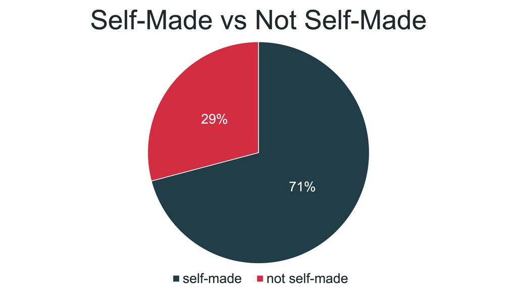

Surely, there exist some lucky people! Apart from the fact that luck can play a big role in people’s lives, this graph shows that there are particularly effective strategies for making money because the majority of the billionaires is self-made.

From here on, the analysis is focused on self-made billionaires.

## 2. How Did the Self-Made Billioniares Create Their Wealth?

So, how did they make their money?

To answer this question I divided the list into categories.

```sql
SELECT category, count(category)
FROM billionaires.forbes_billionaires
WHERE self_made = TRUE
GROUP BY category
ORDER BY count DESC;
```

Displaying records 1 - 10

| category | count |
| --- | --- |
| Technology | 324 |
| Finance & Investments | 299 |
| Manufacturing | 244 |
| Fashion & Retail | 156 |
| Healthcare | 153 |
| Real Estate | 141 |
| Food & Beverage | 109 |
| Diversified | 83 |
| Media & Entertainment | 71 |
| Energy | 71 |

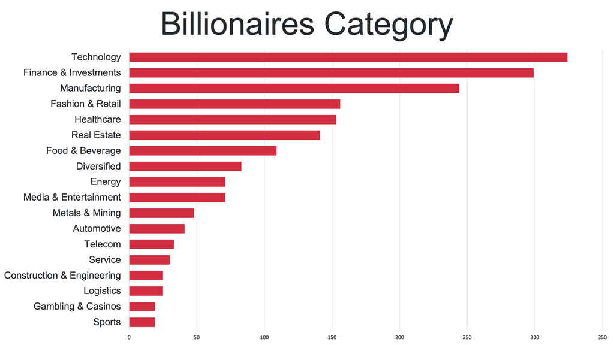

The graph shows that the top three categories in which the billionaires chose to make the money were **Technology**, **Finance & Investments** and **Manufacturing.**

It seems that in today’s world, using some form of technology as a leverage to make money is the most effective strategy. Most of the technology billionaires sell products or provide services that are based in technology. Some sell online platforms. Some sell softwares to make work easier for computer users. Some provide SNS. Some does E-commerce. Some sell online games.

Next, investing is another really effective way to make money. In my opinion, investing is the strategy that best fits the idea of using money to make money. Even though investing can be more risky than other strategies, it can be a really effective strategy that can make a lot of money by investing very little time.

Lastly, many billionaires still employ the old-fashioned method of selling physical products to create their fortunes. The graph shows that manufaturing products for sale is still one of the most effective strategies for making money.

## 3. In What Countries Are These Billionaires Based In?

```sql
SELECT country, count(country)
FROM billionaires.forbes_billionaires
WHERE self_made = TRUE
GROUP BY country
ORDER BY count DESC;
```

Displaying records 1 - 10

| country | count |
| --- | --- |
| China | 553 |
| United States | 550 |
| India | 74 |
| Russia | 65 |
| United Kingdom | 64 |
| Hong Kong | 45 |
| Switzerland | 40 |
| Germany | 36 |
| Canada | 32 |
| Japan | 31 |

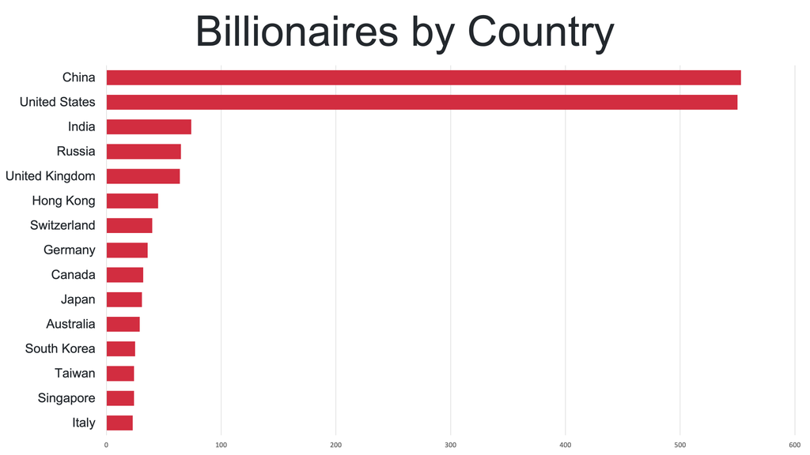

**China** and **United States** were the top 2 countries with most self-made billionaires, beating other countries by a large margin.

## Deeper Dive Into the United States Billionaires

Since I live in the United States, I decided to do a deeper analysis on billionaires in the United States who were self-made.

```sql
-- Average ages of self-made billionaires in the United States.

SELECT AVG(age)
FROM billionaires.forbes_billionaires
WHERE self_made = TRUE;
```

1 records

| avg |
| --- |
| 63.48786 |

```sql
-- The oldest age of self-made billionaires in the United States.

SELECT MAX(age)
FROM billionaires.forbes_billionaires
WHERE self_made = TRUE;
```

1 records

| max |
| --- |
| 100 |

```sql
-- The youngest age of self-made billionaires in the United States.

SELECT MIN(age)
FROM billionaires.forbes_billionaires
WHERE self_made = TRUE;
```

1 records

| min |
| --- |
| 25 |

### The Younger Generation of U.S. Billionaires

I thought that the wealth generation methods of the younger U.S. billionaires would provide greater insight than those of the older billionaires into how to make money more effectively in the current world, where everything is changing so rapidly. So I analyzed the younger generation of the U.S billionaires who were under the age of **63**.

```sql
SELECT category, count(category)
FROM billionaires.forbes_billionaires
WHERE self_made = TRUE AND country = 'United States' AND age <63
GROUP BY category
ORDER BY count DESC;
```

Displaying records 1 - 10

| category | count |
| --- | --- |
| Technology | 96 |
| Finance & Investments | 74 |
| Media & Entertainment | 14 |
| Fashion & Retail | 9 |
| Food & Beverage | 8 |
| Healthcare | 7 |
| Real Estate | 6 |
| Sports | 3 |
| Automotive | 3 |
| Energy | 2 |

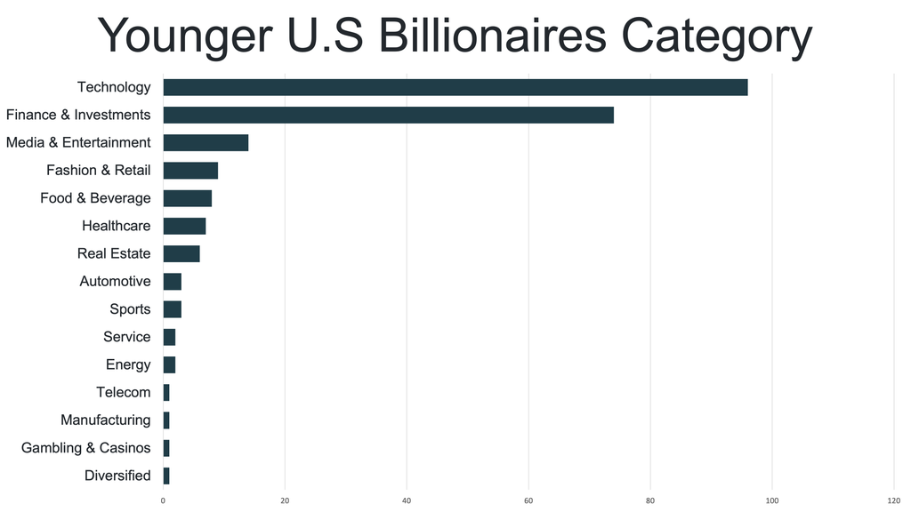

**Technology** and **Finance & Investments** were still the top 2 categories in which the younger generation of U.S billionaires amassed their wealth. However, significantly, Manufacturing was no longer a popular category. Instead, **Media & Entertainment** had replaced Manufacturing as the third place in the list.

## Conclusion

In conclusion, I noticed that some of the most effective money making strategies in the United States currently included selling products or providing services that are based in technology. This makes sense because with the boom of internet, it became possible for a person to reach billions of people all over the world. And using those connections as a leverage was one of the most effective strategies for making money in today’s world. Some of the business models included selling softwares, providing platforms, doing e-commerce, providing SNS and selling online games and apps.

And then, there was investing. With right decisions, one can make a large amount of money very quickly, especially if one has a large capital. And I believe that the effectiveness of investing in making money is reflected in the rising trends of people viewing investing as a necessity.

All in all, accumulating a large sum of money rather quickly is not easy. However, this analysis showed that there exists ways to do just that. And possibly, the insights gained through this analysis can direct one in the better ways of making money more effectively. If you have time, it might not be a bad idea to become more knowledgeable about technology and investing and constantly seek out opportunities to apply those knowledge.